# Practical Machine Learning Project

jagodag

Sunday, October 25, 2015

### Executive Summary

Using devices such as Jawbone Up, Nike FuelBand, and Fitbit it is now possible to collect a large amount of data about personal activity relatively inexpensively. These type of devices are part of the quantified self movement - a group of enthusiasts who take measurements about themselves regularly to improve their health, to find patterns in their behavior, or because they are tech geeks. One thing that people regularly do is quantify how much of a particular activity they do, but they rarely quantify how well they do it. In this project, your goal will be to use data from accelerometers on the belt, forearm, arm, and dumbell of 6 participants. They were asked to perform barbell lifts correctly and incorrectly in 5 different ways.

The goal of your project is to predict the manner in which they did the exercise. This is the “classe” variable in the training set. You may use any of the other variables to predict with. You should create a report describing how you built your model, how you used cross validation, what you think the expected out of sample error is, and why you made the choices you did. You will also use your prediction model to predict 20 different test cases.

### Step by Step Explanation of the work

First of all, I’m going to load all needed libraries.

```r
library(ElemStatLearn)
library(caret)
library(rpart)
library(randomForest)
```

The next step will be getting trainset and test set, and preparing data for prediction ( removing NA’s and getting rid of unknown columns). Then we will split training data into training and testing set ( 60 vs 40). Then we are going to validate our sets.

```r
trainset <- read.csv("pml-training.csv", header=TRUE, sep=",", na.strings=c("NA",""))
testset <- read.csv("pml-testing.csv", header=TRUE, sep=",", na.strings=c("NA",""))
```

```r
trainset <- trainset[,-1]
inTrain = createDataPartition(trainset$classe, p=0.60, list=FALSE)
training = trainset[inTrain,]
validating = trainset[-inTrain,]
```

```r
sum((colSums(!is.na(training[,-ncol(training)])) < 0.6*nrow(training)))
```

```
## [1] 100
```

```r
SCols <- c((colSums(!is.na(training[,-ncol(training)])) >= 0.6*nrow(training)))
training   <-  training[,SCols]
validating <- validating[,SCols]
```

I will be using Random Forest Model for predictive analysis on training data.

```r
m<- randomForest(classe~.,data=training)
print(m)
```

```
##
## Call:
##  randomForest(formula = classe ~ ., data = training)
##                Type of random forest: classification
##                      Number of trees: 500
## No. of variables tried at each split: 7
##
##         OOB estimate of  error rate: 0.17%
## Confusion matrix:
##      A    B    C    D    E  class.error
## A 3347    1    0    0    0 0.0002986858
## B    2 2277    0    0    0 0.0008775779
## C    0    3 2049    2    0 0.0024342746
## D    0    0    6 1921    3 0.0046632124
## E    0    0    0    3 2162 0.0013856813
```

```r
importance(m)
```

```
##                      MeanDecreaseGini
## user_name                  87.6843306
## raw_timestamp_part_1      995.3004326
## raw_timestamp_part_2       10.5127120
## cvtd_timestamp           1388.8027459
## new_window                  0.1954924
## num_window                564.8024444
## roll_belt                 530.8629457
## pitch_belt                304.1182223
## yaw_belt                  349.5828969
## total_accel_belt          113.8832083
## gyros_belt_x               36.8662523
## gyros_belt_y               48.5159043
## gyros_belt_z              116.3402533
## accel_belt_x               63.6709281
## accel_belt_y               74.0961330
## accel_belt_z              191.5301802
## magnet_belt_x             114.7726784
## magnet_belt_y             200.3869759
## magnet_belt_z             176.5324921
## roll_arm                  116.3813381
## pitch_arm                  55.1391299
## yaw_arm                    74.7718005
## total_accel_arm            28.9179114
## gyros_arm_x                39.9816819
## gyros_arm_y                40.0329802
## gyros_arm_z                18.0942863
## accel_arm_x                91.2175911
## accel_arm_y                52.8138998
## accel_arm_z                40.8823738
## magnet_arm_x               82.5103524
## magnet_arm_y               73.2521184
## magnet_arm_z               56.2913649
## roll_dumbbell             185.3273398
## pitch_dumbbell             78.7660437
## yaw_dumbbell              115.3137242
## total_accel_dumbbell      116.7784377
## gyros_dumbbell_x           41.7603927
## gyros_dumbbell_y           90.6036659
## gyros_dumbbell_z           25.4550874
## accel_dumbbell_x          132.0753395
## accel_dumbbell_y          183.5368482
## accel_dumbbell_z          139.5772147
## magnet_dumbbell_x         227.5939885
## magnet_dumbbell_y         306.4187759
## magnet_dumbbell_z         290.9764213
## roll_forearm              255.0737173
## pitch_forearm             296.7467043
## yaw_forearm                54.4778502
## total_accel_forearm        31.8797502
## gyros_forearm_x            24.9037948
## gyros_forearm_y            38.3956461
## gyros_forearm_z            26.6134686
## accel_forearm_x           125.0528908
## accel_forearm_y            40.8591194
## accel_forearm_z            98.9774158
## magnet_forearm_x           74.4086506
## magnet_forearm_y           73.2806820
## magnet_forearm_z           96.0129523
```

```r
confusionMatrix(predict(m,newdata=validating[,-ncol(validating)]),validating$classe)
```

```
## Confusion Matrix and Statistics
##
##           Reference
## Prediction    A    B    C    D    E
##          A 2232    0    0    0    0
##          B    0 1518    1    0    0
##          C    0    0 1365    5    0
##          D    0    0    2 1281    0
##          E    0    0    0    0 1442
##
## Overall Statistics
##
##                Accuracy : 0.999
##                  95% CI : (0.998, 0.9996)
##     No Information Rate : 0.2845
##     P-Value [Acc > NIR] : < 2.2e-16
##
##                   Kappa : 0.9987
##  Mcnemar's Test P-Value : NA
##
## Statistics by Class:
##
##                      Class: A Class: B Class: C Class: D Class: E
## Sensitivity            1.0000   1.0000   0.9978   0.9961   1.0000
## Specificity            1.0000   0.9998   0.9992   0.9997   1.0000
## Pos Pred Value         1.0000   0.9993   0.9964   0.9984   1.0000
## Neg Pred Value         1.0000   1.0000   0.9995   0.9992   1.0000
## Prevalence             0.2845   0.1935   0.1744   0.1639   0.1838
## Detection Rate         0.2845   0.1935   0.1740   0.1633   0.1838
## Detection Prevalence   0.2845   0.1936   0.1746   0.1635   0.1838
## Balanced Accuracy      1.0000   0.9999   0.9985   0.9979   1.0000
```

Now let’s check the accuracy of the model.

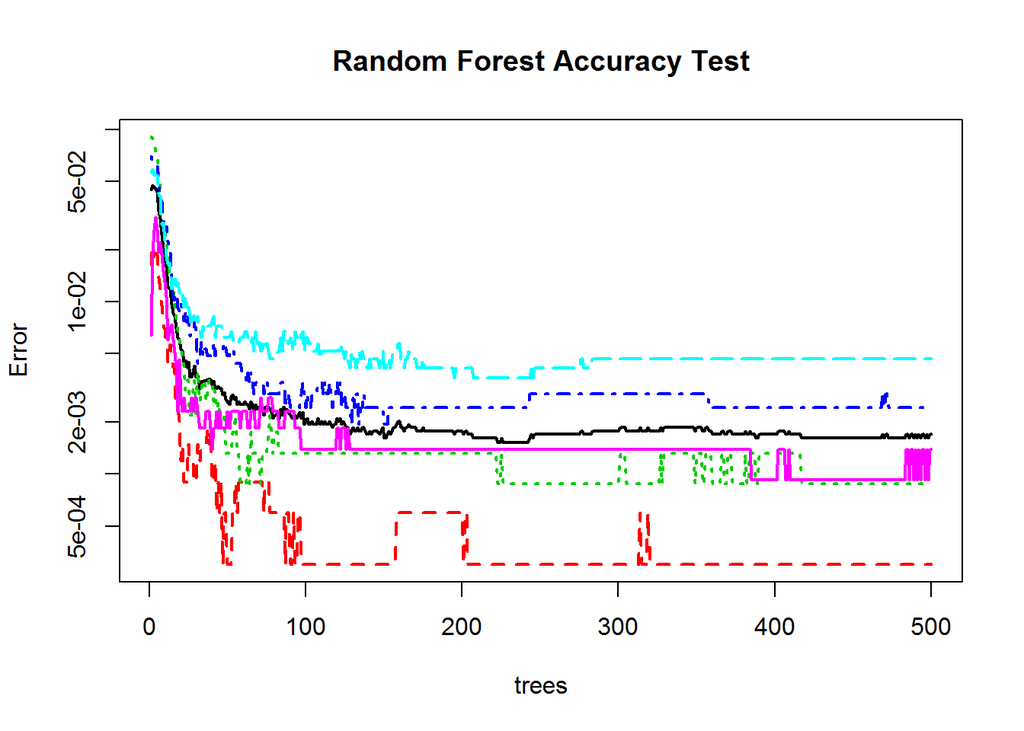

```r
acc<-c(as.numeric(predict(m,newdata=validating[,-ncol(validating)])==validating$classe))
acc<-sum(acc)*100/nrow(validating)
plot(m, log ="y", lwd = 2, main = "Random Forest Accuracy Test")
```

Now we are going apply the test to the testing set to see how it beahves.

```r
testset <- testset[,-1]
testset <- testset[ ,SCols]
testset <- testset[,-ncol(testset)]
testing <- rbind(training[100, -59] , testset)
row.names(testing) <- c(100, 1:20)
```

Let’s check what the Out of sample erros estimation.

```r
pred <- predict(m,newdata=testing[-1,])
print(pred)
```

```
##  1  2  3  4  5  6  7  8  9 10 11 12 13 14 15 16 17 18 19 20
##  B  A  B  A  A  E  D  B  A  A  B  C  B  A  E  E  A  B  B  B
## Levels: A B C D E
```

```r
# true accuracy of the predicted model
p2 <- predict(m, validating)
outOfSampleError.accuracy <- sum(p2 == validating$classe)/length(p2)
outOfSampleError.accuracy
```

```
## [1] 0.9989804
```

```r
outOfSampleError <- 1 - outOfSampleError.accuracy
outOfSampleError
```

```
## [1] 0.001019628
```

```r
e <- outOfSampleError * 100
paste0("Out of sample error estimation: ", round(e, digits = 2), "%")
```

```
## [1] "Out of sample error estimation: 0.1%"
```

From the above, we can conclude that accuracy is quite good so the model does the job.

### Submission to coursera

```r
write_files <- function(x) {
  n <- length(x)
  for (i in 1:n) {
    filename <- paste0("problem_id", i, ".txt")
    write.table(x[i], file=filename, quote=FALSE, row.names=FALSE,col.names=FALSE)
  }
}

write_files(pred)
```